# Exploring Worldwide Trends in Women's Fertility, Per Capita Income, and Life Expectancy

- Introduction
- Data Wrangling
- Exploratory Data Analysis
- Conclusions
- Resources

## Introduction

The [Gapminder World dataset](https://www.gapminder.org/data/) contains data points on various socioeconomic metrics for the world's countries over the past 200 years. The exploration described below focuses on trends in women's fertility, per capita income, and life expectancy. The specific questions explored are:

- which countries currently have the highest and lowest fertility rates?
- how have the fertility rates for those countries been trending in the last 20 years?
- which sub-regions of the world are currently the richest, and which are the poorest?
- how has that wealth pattern changed over the past 200 years?
- which sub-regions of the world currently have the highest and lowest life expectancies?
- how does life expectancy relate to income over the past 100 years?

**NOTE**: This exploration was not intended to imply causation between any of the examined metrics. Any trends shown here are at best correlation rather than causation.

## Data Wrangling

### General Properties

```python
import pandas as pd
import numpy as np
from numpy.polynomial import Polynomial
import matplotlib.pyplot as plt
import seaborn as sns
import math

%matplotlib inline
```

```python
def read_data(filename: str, sep: str = ','):
    return pd.read_csv(f'datasets/{filename}', sep=sep)
```

#### Fertility

```python
fertility_df = read_data('children_per_woman_total_fertility.csv')
fertility_df.head()
```

|  | country | 1800 | 1801 | 1802 | 1803 | 1804 | 1805 | 1806 | 1807 | 1808 | ... | 2091 | 2092 | 2093 | 2094 | 2095 | 2096 | 2097 | 2098 | 2099 | 2100 |
| --- | --- | --- | --- | --- | --- | --- | --- | --- | --- | --- | --- | --- | --- | --- | --- | --- | --- | --- | --- | --- | --- |
| 0 | Aruba | 5.64 | 5.64 | 5.64 | 5.64 | 5.64 | 5.64 | 5.64 | 5.64 | 5.64 | ... | 1.82 | 1.82 | 1.82 | 1.82 | 1.82 | 1.82 | 1.82 | 1.82 | 1.83 | 1.83 |
| 1 | Afghanistan | 7.00 | 7.00 | 7.00 | 7.00 | 7.00 | 7.00 | 7.00 | 7.00 | 7.00 | ... | 1.74 | 1.74 | 1.74 | 1.74 | 1.74 | 1.74 | 1.74 | 1.74 | 1.74 | 1.74 |
| 2 | Angola | 6.93 | 6.93 | 6.93 | 6.93 | 6.93 | 6.93 | 6.93 | 6.94 | 6.94 | ... | 2.54 | 2.52 | 2.50 | 2.48 | 2.47 | 2.45 | 2.43 | 2.42 | 2.40 | 2.40 |
| 3 | Albania | 4.60 | 4.60 | 4.60 | 4.60 | 4.60 | 4.60 | 4.60 | 4.60 | 4.60 | ... | 1.78 | 1.78 | 1.78 | 1.79 | 1.79 | 1.79 | 1.79 | 1.79 | 1.79 | 1.79 |
| 4 | Netherlands Antilles | 5.80 | 5.80 | 5.80 | 5.80 | 5.80 | 5.80 | 5.80 | 5.80 | 5.80 | ... | 2.00 | 2.00 | 2.01 | 2.01 | 2.01 | 2.01 | 2.01 | 2.02 | 2.02 | 2.02 |

5 rows × 302 columns

```python
fertility_df.shape
```

```
(202, 302)
```

The dataset contains data for up to 202 countries, and includes projected fertility rates going out to 2100.

```python
fertility_df.info(verbose=True, show_counts=True)
```

```
<class 'pandas.core.frame.DataFrame'>
RangeIndex: 202 entries, 0 to 201
Data columns (total 302 columns):
 #    Column   Non-Null Count  Dtype
---   ------   --------------  -----
 0    country  202 non-null    object
 1    1800     202 non-null    float64
 2    1801     202 non-null    float64
 3    1802     202 non-null    float64
 4    1803     202 non-null    float64
 5    1804     202 non-null    float64
 6    1805     202 non-null    float64
 7    1806     202 non-null    float64
 8    1807     202 non-null    float64
 9    1808     202 non-null    float64
```

[output cut: 294 more lines]

All the numbers are already floats, and there's very little missing data (only one country doesn't have data starting from 2014).

```python
fertility_df.duplicated().sum()
```

```
0
```

There are no duplicated rows.

#### Per Capita Income

```python
income_per_person_df = read_data('income_per_person_gdppercapita_ppp_inflation_adjusted.csv')
income_per_person_df.head()
```

|  | country | 1800 | 1801 | 1802 | 1803 | 1804 | 1805 | 1806 | 1807 | 1808 | ... | 2041 | 2042 | 2043 | 2044 | 2045 | 2046 | 2047 | 2048 | 2049 | 2050 |
| --- | --- | --- | --- | --- | --- | --- | --- | --- | --- | --- | --- | --- | --- | --- | --- | --- | --- | --- | --- | --- | --- |
| 0 | Afghanistan | 683 | 683 | 683 | 683 | 683 | 683 | 683 | 683 | 683 | ... | 2690 | 2750 | 2810 | 2870 | 2930 | 2990 | 3060 | 3120 | 3190 | 3260 |
| 1 | Angola | 700 | 702 | 705 | 709 | 711 | 714 | 718 | 721 | 725 | ... | 8000 | 8170 | 8350 | 8530 | 8710 | 8900 | 9090 | 9280 | 9480 | 9690 |
| 2 | Albania | 755 | 755 | 755 | 755 | 755 | 756 | 756 | 756 | 756 | ... | 25.1k | 25.6k | 26.2k | 26.7k | 27.3k | 27.9k | 28.5k | 29.1k | 29.7k | 30.4k |
| 3 | Andorra | 1360 | 1360 | 1360 | 1360 | 1370 | 1370 | 1370 | 1370 | 1380 | ... | 68.9k | 70.4k | 71.9k | 73.4k | 75k | 76.6k | 78.3k | 80k | 81.7k | 83.4k |
| 4 | United Arab Emirates | 1130 | 1130 | 1140 | 1140 | 1150 | 1150 | 1160 | 1160 | 1160 | ... | 101k | 103k | 105k | 107k | 110k | 112k | 114k | 117k | 119k | 122k |

5 rows × 252 columns

```python
income_per_person_df.shape
```

```
(195, 252)
```

The dataset contains data for up to 195 countries, and includes projected income levels going out to 2050.

```python
income_per_person_df.info(verbose=True, show_counts=True)
```

```
<class 'pandas.core.frame.DataFrame'>
RangeIndex: 195 entries, 0 to 194
Data columns (total 252 columns):
 #    Column   Non-Null Count  Dtype
---   ------   --------------  -----
 0    country  195 non-null    object
 1    1800     195 non-null    int64
 2    1801     195 non-null    int64
 3    1802     195 non-null    int64
 4    1803     195 non-null    int64
 5    1804     195 non-null    int64
 6    1805     195 non-null    int64
 7    1806     195 non-null    int64
 8    1807     195 non-null    int64
 9    1808     195 non-null    int64
```

[output cut: 244 more lines]

There appear to be no empty values, though the data types change from integers to strings beginning from 1901.

```python
income_per_person_df['1808'].unique()
```

```
array([ 683,  725,  756, 1380, 1160, 1770,  582,  858,  968, 2160,  878,
        477, 2730,  676,  543,  992, 1230, 1450, 1640,  757,  691,  655,
       1010, 1040, 1710,  713,  451,  481, 1560, 2780, 1050,  678,  710,
        567,  666,  795,  600,  769,  967, 2170, 1830,  873,  752, 2310,
        796, 1120,  603, 1760, 1070,  592, 1460,  890, 2090,  589,  443,
       3780,  616,  792,  511,  925,  642,  406, 1780, 1090,  971, 1210,
        764, 1310,  718, 1420, 1060, 1650, 1020, 2860, 3210, 1300, 1530,
        991,  576,  436,  628, 1320,  948, 1280,  980, 1250,  903, 1190,
        400,  809, 2230,  704,  649,  954, 1330,  614,  782,  885,  933,
       1200,  671,  444,  598,  396,  612,  506,  978, 1100, 3060, 1580,
        745,  810,  960, 1080,  951,  619,  863,  281, 1680,  946,  765,
        225,  492,  918,  588,  564,  411,  832, 1110, 1610,  791, 1540,
        575,  977, 1850, 1620, 1600, 1490,  555, 1260,  474,  773,  632,
        599,  751, 1400,  799,  814,  637,  525,  872, 2200, 2940,  569,
        950,  976,  663, 1590,  993])
```

```python
income_per_person_df['1908'].unique()
```

```
array(['1120', '774', '1410', '3980', '5770', '6780', '1090', '1480',
       '8700', '6150', '1740', '523', '7290', '1040', '601', '1160',
       '2060', '3070', '2970', '1340', '1190', '1880', '1100', '2310',
       '850', '689', '736', '6620', '9930', '4670', '1070', '682', '1200',
       '857', '883', '1350', '880', '2350', '2130', '2740', '5020',
       '6030', '1360', '6580', '1220', '2040', '1510', '1870', '756',
       '3390', '2340', '611', '5640', '627', '877', '8670', '1140',
       '1030', '993', '691', '637', '2960', '1580', '1990', '2490',
       '2540', '2170', '3630', '1760', '3580', '1150', '4820', '1430',
       '3220', '3160', '4410', '1110', '1780', '2840', '1250', '497',
       '686', '2390', '1260', '3140', '1210', '2560', '2920', '1330',
       '2260', '423', '1280', '6300', '1380', '994', '1060', '652',
       '1860', '705', '1080', '2240', '855', '471', '738', '1630', '403',
       '2280', '2320', '6540', '4200', '976', '961', '8960', '2910',
       '1800', '1440', '835', '3130', '385', '2850', '2800', '732',
       '3560', '559', '900', '863', '2890', '562', '1790', '2940', '871',
       '3660', '881', '1180', '3360', '3740', '3800', '4600', '1370',
       '2300', '726', '1540', '1270', '730', '1010', '2250', '1570',
       '1670', '617', '805', '1900', '5060', '10.4k', '920', '1720',
       '1970', '1290', '895', '2140', '975'], dtype=object)
```

Comparing the unique integer values for 1808 with the unique string values for 1908, it becomes clear that some of the larger numbers are shortened (eg `10.4k` instead of `10400`). This will require further processing to achieve consistency.

```python
income_per_person_df.duplicated().sum()
```

```
0
```

There are no duplicated rows.

#### Life Expectancy

```python
life_expectancy_df = read_data('life_expectancy_years.csv')
life_expectancy_df.head()
```

|  | country | 1800 | 1801 | 1802 | 1803 | 1804 | 1805 | 1806 | 1807 | 1808 | ... | 2091 | 2092 | 2093 | 2094 | 2095 | 2096 | 2097 | 2098 | 2099 | 2100 |
| --- | --- | --- | --- | --- | --- | --- | --- | --- | --- | --- | --- | --- | --- | --- | --- | --- | --- | --- | --- | --- | --- |
| 0 | Afghanistan | 28.2 | 28.2 | 28.2 | 28.2 | 28.2 | 28.2 | 28.1 | 28.1 | 28.1 | ... | 75.5 | 75.7 | 75.8 | 76.0 | 76.1 | 76.2 | 76.4 | 76.5 | 76.6 | 76.8 |
| 1 | Angola | 27.0 | 27.0 | 27.0 | 27.0 | 27.0 | 27.0 | 27.0 | 27.0 | 27.0 | ... | 78.8 | 79.0 | 79.1 | 79.2 | 79.3 | 79.5 | 79.6 | 79.7 | 79.9 | 80.0 |
| 2 | Albania | 35.4 | 35.4 | 35.4 | 35.4 | 35.4 | 35.4 | 35.4 | 35.4 | 35.4 | ... | 87.4 | 87.5 | 87.6 | 87.7 | 87.8 | 87.9 | 88.0 | 88.2 | 88.3 | 88.4 |
| 3 | Andorra | NaN | NaN | NaN | NaN | NaN | NaN | NaN | NaN | NaN | ... | NaN | NaN | NaN | NaN | NaN | NaN | NaN | NaN | NaN | NaN |
| 4 | United Arab Emirates | 30.7 | 30.7 | 30.7 | 30.7 | 30.7 | 30.7 | 30.7 | 30.7 | 30.7 | ... | 82.4 | 82.5 | 82.6 | 82.7 | 82.8 | 82.9 | 83.0 | 83.1 | 83.2 | 83.3 |

5 rows × 302 columns

```python
life_expectancy_df.shape
```

```
(195, 302)
```

The dataset contains data for up to 195 countries, and includes projected life expectancy levels going out to 2100.

```python
life_expectancy_df.info(verbose=True, show_counts=True)
```

```
<class 'pandas.core.frame.DataFrame'>
RangeIndex: 195 entries, 0 to 194
Data columns (total 302 columns):
 #    Column   Non-Null Count  Dtype
---   ------   --------------  -----
 0    country  195 non-null    object
 1    1800     186 non-null    float64
 2    1801     186 non-null    float64
 3    1802     186 non-null    float64
 4    1803     186 non-null    float64
 5    1804     186 non-null    float64
 6    1805     186 non-null    float64
 7    1806     186 non-null    float64
 8    1807     186 non-null    float64
 9    1808     186 non-null    float64
```

[output cut: 294 more lines]

A number of countries are missing data for the years before 1950 and after 2019. All the numbers are already formatted as floats.

```python
life_expectancy_df.duplicated().sum()
```

```
0
```

There are no duplicated rows.

### Further Data Processing

#### Fertility

The first step is to identify the row(s) that contain missing data.

```python
fertility_df[np.isnan(fertility_df['2014'])].loc[:,'2014':]
```

|  | 2014 | 2015 | 2016 | 2017 | 2018 | 2019 | 2020 | 2021 | 2022 | 2023 | ... | 2091 | 2092 | 2093 | 2094 | 2095 | 2096 | 2097 | 2098 | 2099 | 2100 |
| --- | --- | --- | --- | --- | --- | --- | --- | --- | --- | --- | --- | --- | --- | --- | --- | --- | --- | --- | --- | --- | --- |
| 73 | NaN | NaN | NaN | NaN | NaN | NaN | NaN | NaN | NaN | NaN | ... | NaN | NaN | NaN | NaN | NaN | NaN | NaN | NaN | NaN | NaN |

1 rows × 87 columns

There's only one row that has missing data, so it can be dropped from the dataset.

```python
fertility_df.dropna(inplace=True)
fertility_df.shape
```

```
(201, 302)
```

```python
fertility_df.info(verbose=True, show_counts=True)
```

```
<class 'pandas.core.frame.DataFrame'>
Int64Index: 201 entries, 0 to 201
Data columns (total 302 columns):
 #    Column   Non-Null Count  Dtype
---   ------   --------------  -----
 0    country  201 non-null    object
 1    1800     201 non-null    float64
 2    1801     201 non-null    float64
 3    1802     201 non-null    float64
 4    1803     201 non-null    float64
 5    1804     201 non-null    float64
 6    1805     201 non-null    float64
 7    1806     201 non-null    float64
 8    1807     201 non-null    float64
 9    1808     201 non-null    float64
```

[output cut: 294 more lines]

Now there's data for all 201 countries remaining. This state of the dataset will be sufficient to answer the questions for fertility rate.

```python
def countries_to_lowercase(country_name: str) -> str:
    return country_name.strip().lower().replace(' ', '_').replace('-', '_')
```

```python
fertility_df.country = fertility_df.country.apply(countries_to_lowercase)
fertility_df.head()
```

|  | country | 1800 | 1801 | 1802 | 1803 | 1804 | 1805 | 1806 | 1807 | 1808 | ... | 2091 | 2092 | 2093 | 2094 | 2095 | 2096 | 2097 | 2098 | 2099 | 2100 |
| --- | --- | --- | --- | --- | --- | --- | --- | --- | --- | --- | --- | --- | --- | --- | --- | --- | --- | --- | --- | --- | --- |
| 0 | aruba | 5.64 | 5.64 | 5.64 | 5.64 | 5.64 | 5.64 | 5.64 | 5.64 | 5.64 | ... | 1.82 | 1.82 | 1.82 | 1.82 | 1.82 | 1.82 | 1.82 | 1.82 | 1.83 | 1.83 |
| 1 | afghanistan | 7.00 | 7.00 | 7.00 | 7.00 | 7.00 | 7.00 | 7.00 | 7.00 | 7.00 | ... | 1.74 | 1.74 | 1.74 | 1.74 | 1.74 | 1.74 | 1.74 | 1.74 | 1.74 | 1.74 |
| 2 | angola | 6.93 | 6.93 | 6.93 | 6.93 | 6.93 | 6.93 | 6.93 | 6.94 | 6.94 | ... | 2.54 | 2.52 | 2.50 | 2.48 | 2.47 | 2.45 | 2.43 | 2.42 | 2.40 | 2.40 |
| 3 | albania | 4.60 | 4.60 | 4.60 | 4.60 | 4.60 | 4.60 | 4.60 | 4.60 | 4.60 | ... | 1.78 | 1.78 | 1.78 | 1.79 | 1.79 | 1.79 | 1.79 | 1.79 | 1.79 | 1.79 |
| 4 | netherlands_antilles | 5.80 | 5.80 | 5.80 | 5.80 | 5.80 | 5.80 | 5.80 | 5.80 | 5.80 | ... | 2.00 | 2.00 | 2.01 | 2.01 | 2.01 | 2.01 | 2.01 | 2.02 | 2.02 | 2.02 |

5 rows × 302 columns

The country names have been converted to lowercase, and the spaces and dashes in them have been converted to underscores to enable easier manipulation with the code.

#### Income Per Capita

First of all, the differences in number format need to be rectified by converting all the strings to integers.

```python
from typing import Union

def has_million(value: Union[str, int]) -> bool:
    return value.endswith('m') if isinstance(value, str) else False

def has_thousands(value: Union[str, int]) -> bool:
    return value.endswith('k') if isinstance(value, str) else False
```

```python
print('Number of cells containing millions formatted with "m" suffix:', sum([np.fromiter((val for val in income_per_person_df[col].unique() if has_million(val)), dtype='S128').size for col in income_per_person_df.columns[1:]]))
```

```
Number of cells containing millions formatted with "m" suffix: 0
```

```python
print('Number of cells containing thousands formatted with "k" suffix:', sum([np.fromiter((val for val in income_per_person_df[col].unique() if has_thousands(val)), dtype='S128').size for col in income_per_person_df.columns[1:]]))
```

```
Number of cells containing thousands formatted with "k" suffix: 8087
```

So only values containing thousands need to be reformatted.

```python
income_per_person_df.iloc[:,1:].dtypes.unique()
```

```
array([dtype('int64'), dtype('O')], dtype=object)
```

Those are the unique datatypes before reformatting, where `dtype('O')` represents strings and `dtype('int64')` represents integers.

```python
for col in income_per_person_df.columns[1:]:
    if income_per_person_df[col].dtype != int:
        income_per_person_df[col] = income_per_person_df[col].apply(lambda x: int(float(x[:-1]) * 1000) if has_thousands(x) else int(x))

income_per_person_df.iloc[:, 1:].dtypes.unique()
```

```
array([dtype('int64')], dtype=object)
```

The loop above iterates over all the year columns and converts the values in the column to integers if they're currently strings. The final output after the loop shows that integer is the only unique data type now.

Next, the sub-regions need to be added to this dataset. Currently only countries are specified, so both the sub-region and country code will be added.

```python
income_per_person_df.country = income_per_person_df.country.apply(countries_to_lowercase)
```

The country names have been converted to lowercase, and the spaces and dashes in them have been converted to underscores to enable easier manipulation with the code.

```python
country_df = read_data('unsd-methodology.csv', sep=';')
country_df.head()
```

|  | Global Code | Global Name | Region Code | Region Name | Sub-region Code | Sub-region Name | Intermediate Region Code | Intermediate Region Name | Country or Area | M49 Code | ISO-alpha2 Code | ISO-alpha3 Code | Least Developed Countries (LDC) | Land Locked Developing Countries (LLDC) | Small Island Developing States (SIDS) |
| --- | --- | --- | --- | --- | --- | --- | --- | --- | --- | --- | --- | --- | --- | --- | --- |
| 0 | 1 | World | NaN | NaN | NaN | NaN | NaN | NaN | Antarctica | 10 | AQ | ATA | NaN | NaN | NaN |
| 1 | 1 | World | 2.0 | Africa | 15.0 | Northern Africa | NaN | NaN | Algeria | 12 | DZ | DZA | NaN | NaN | NaN |
| 2 | 1 | World | 2.0 | Africa | 15.0 | Northern Africa | NaN | NaN | Egypt | 818 | EG | EGY | NaN | NaN | NaN |
| 3 | 1 | World | 2.0 | Africa | 15.0 | Northern Africa | NaN | NaN | Libya | 434 | LY | LBY | NaN | NaN | NaN |
| 4 | 1 | World | 2.0 | Africa | 15.0 | Northern Africa | NaN | NaN | Morocco | 504 | MA | MAR | NaN | NaN | NaN |

To get the country sub-regions, a new dataset containing the country name, sub-region, and country code has been loaded.

```python
country_df.rename(columns=lambda x: x.strip().lower().replace(' ', '_').replace('-', '_'), inplace=True)
country_df = country_df.loc[:,['sub_region_name', 'country_or_area', 'iso_alpha3_code']]
country_df.country_or_area = country_df.country_or_area.apply(countries_to_lowercase)
country_df.head()
```

|  | sub_region_name | country_or_area | iso_alpha3_code |
| --- | --- | --- | --- |
| 0 | NaN | antarctica | ATA |
| 1 | Northern Africa | algeria | DZA |
| 2 | Northern Africa | egypt | EGY |
| 3 | Northern Africa | libya | LBY |
| 4 | Northern Africa | morocco | MAR |

The code above does the following in order:

- changes the column names in the country dataframe to lowercase
- removes all columns except the sub-region, name and country code
- converts the country names to lowercase and converts the dashes and spaces to underscores

These steps leave data that can be more easily merged with the income dataframe to add the needed sub-regions.

Before performing the merge, a check is needed to confirm which of the country names can be merged smoothly.

```python
non_common_countries = (set(income_per_person_df.country) | set(country_df.country_or_area)) - (set(income_per_person_df.country) & set(country_df.country_or_area))
non_common_countries
```

```
{'american_samoa',
 'anguilla',
 'antarctica',
 'aruba',
 'bermuda',
 'bolivia',
 'bolivia_(plurinational_state_of)',
 'bonaire,_sint_eustatius_and_saba',
 'bouvet_island',
 'british_indian_ocean_territory',
 'british_virgin_islands',
 'brunei',
 'brunei_darussalam',
 'cabo_verde',
 'cape_verde',
 'cayman_islands',
 'china,_hong_kong_special_administrative_region',
 'china,_macao_special_administrative_region',
 'christmas_island',
 'cocos_(keeling)_islands',
 'congo',
 'congo,_dem._rep.',
 'congo,_rep.',
 'cook_islands',
 "cote_d'ivoire",
 'curaçao',
 'czech_republic',
 'czechia',
 'côte_d’ivoire',
 "democratic_people's_republic_of_korea",
 'democratic_republic_of_the_congo',
 'falkland_islands_(malvinas)',
 'faroe_islands',
 'french_guiana',
 'french_polynesia',
 'french_southern_territories',
 'gibraltar',
 'greenland',
 'guadeloupe',
 'guam',
```

[output cut: 57 more lines]

```
 'türkiye',
 'united_kingdom',
 'united_kingdom_of_great_britain_and_northern_ireland',
 'united_republic_of_tanzania',
 'united_states',
 'united_states_minor_outlying_islands',
 'united_states_of_america',
 'united_states_virgin_islands',
 'venezuela',
 'venezuela_(bolivarian_republic_of)',
 'viet_nam',
 'vietnam',
 'wallis_and_futuna_islands',
 'western_sahara',
 'åland_islands'}
```

```python
non_common_from_income = []
non_common_from_country = []
for country_name in non_common_countries:
    if income_per_person_df.query(f'country == "{country_name}"').size > 0:
        non_common_from_income.append(country_name)
    else:
        non_common_from_country.append(country_name)

print('Non common names from the country dataframe:\n', non_common_from_country, '\n\n')
print('Non common names from the income dataframe:\n', non_common_from_income)
```

```
Non common names from the country dataframe:
 ['saint_helena', 'aruba', 'french_guiana', 'state_of_palestine', 'czechia', 'montserrat', 'holy_see', 'united_states_minor_outlying_islands', 'british_indian_ocean_territory', 'mayotte', 'congo', 'bolivia_(plurinational_state_of)', 'democratic_republic_of_the_congo', 'russian_federation', 'cocos_(k…


Non common names from the income dataframe:
 ['palestine', 'st._vincent_and_the_grenadines', 'czech_republic', 'venezuela', 'turkey', 'moldova', 'vietnam', "cote_d'ivoire", 'kyrgyz_republic', 'st._kitts_and_nevis', 'slovak_republic', 'lao', 'russia', 'south_korea', 'st._lucia', 'taiwan', 'congo,_rep.', 'bolivia', 'cape_verde', 'iran', 'tanzan…
```

The above are the country names that are present in only one of the dataframes. After comparing both lists to identify slight spelling differences, the following map of the matching names was created:

```python
different_spellings = {
    'bolivia': 'bolivia_(plurinational_state_of)',
    'brunei': 'brunei_darussalam',
    'cape_verde': 'cabo_verde',
    "cote_d'ivoire": "côte_d’ivoire",
    'hong_kong,_china': 'china,_hong_kong_special_administrative_region',
    'congo,_rep.': 'congo',
    'congo,_dem._rep.': 'democratic_republic_of_the_congo',
    'czech_republic': 'czechia',
    'south_korea': 'republic_of_korea',
    'north_korea': "democratic_people's_republic_of_korea",
    'iran': 'iran_(islamic_republic_of)',
    'kyrgyz_republic': 'kyrgyzstan',
    'lao': "lao_people's_democratic_republic",
    'micronesia,_fed._sts.': 'micronesia_(federated_states_of)',
    'moldova': 'republic_of_moldova',
    'russia': 'russian_federation',
    'st._lucia': 'saint_lucia',
    'st._kitts_and_nevis': 'saint_kitts_and_nevis',
    'st._vincent_and_the_grenadines': 'saint_vincent_and_the_grenadines',
    'syria': 'syrian_arab_republic',
    'slovak_republic': 'slovakia',
    'palestine': 'state_of_palestine',
    'turkey': 'türkiye',
    'united_kingdom': 'united_kingdom_of_great_britain_and_northern_ireland',
    'tanzania': 'united_republic_of_tanzania',
    'united_states': 'united_states_of_america',
    'vietnam': 'viet_nam',
    'venezuela': 'venezuela_(bolivarian_republic_of)',
}
```

Now the names need to be updated:

```python
# reverse the keys and values to fit what we actually need
different_spellings = {val: key for key, val in different_spellings.items()}

# change the names in the countries df
country_df.country_or_area = country_df.country_or_area.apply(lambda x: different_spellings[x] if x in different_spellings else x)
```

Now the merge can proceed:

```python
merged_income_country = pd.merge(left=income_per_person_df, right=country_df, left_on='country', right_on='country_or_area', how='outer')
merged_income_country.head()
```

|  | country | 1800 | 1801 | 1802 | 1803 | 1804 | 1805 | 1806 | 1807 | 1808 | ... | 2044 | 2045 | 2046 | 2047 | 2048 | 2049 | 2050 | sub_region_name | country_or_area | iso_alpha3_code |
| --- | --- | --- | --- | --- | --- | --- | --- | --- | --- | --- | --- | --- | --- | --- | --- | --- | --- | --- | --- | --- | --- |
| 0 | afghanistan | 683.0 | 683.0 | 683.0 | 683.0 | 683.0 | 683.0 | 683.0 | 683.0 | 683.0 | ... | 2870.0 | 2930.0 | 2990.0 | 3060.0 | 3120.0 | 3190.0 | 3260.0 | Southern Asia | afghanistan | AFG |
| 1 | angola | 700.0 | 702.0 | 705.0 | 709.0 | 711.0 | 714.0 | 718.0 | 721.0 | 725.0 | ... | 8530.0 | 8710.0 | 8900.0 | 9090.0 | 9280.0 | 9480.0 | 9690.0 | Sub-Saharan Africa | angola | AGO |
| 2 | albania | 755.0 | 755.0 | 755.0 | 755.0 | 755.0 | 756.0 | 756.0 | 756.0 | 756.0 | ... | 26700.0 | 27300.0 | 27900.0 | 28500.0 | 29100.0 | 29700.0 | 30400.0 | Southern Europe | albania | ALB |
| 3 | andorra | 1360.0 | 1360.0 | 1360.0 | 1360.0 | 1370.0 | 1370.0 | 1370.0 | 1370.0 | 1380.0 | ... | 73400.0 | 75000.0 | 76600.0 | 78300.0 | 80000.0 | 81700.0 | 83400.0 | Southern Europe | andorra | AND |
| 4 | united_arab_emirates | 1130.0 | 1130.0 | 1140.0 | 1140.0 | 1150.0 | 1150.0 | 1160.0 | 1160.0 | 1160.0 | ... | 107000.0 | 110000.0 | 112000.0 | 114000.0 | 117000.0 | 119000.0 | 122000.0 | Western Asia | united_arab_emirates | ARE |

5 rows × 255 columns

The merge is an outer merge to preserve the rows that don't merge smoothly.

It appears the `country` and `country_or_area` fields merged as expected.

```python
missing_country_or_area = merged_income_country[merged_income_country.country_or_area.isna()].loc[:, ['country', 'country_or_area']]
missing_country_or_area.shape
```

```
(1, 2)
```

However it looks like one country wasn't merged successfully because it's only present in the income dataframe.

```python
missing_country = merged_income_country[merged_income_country.country.isna()].loc[:, ['country', 'country_or_area']].sort_values(by='country_or_area')
missing_country.shape
```

```
(55, 2)
```

Similarly, 55 other countries were also not merged successfully because they're only present in the country dataframe.

```python
rows_with_incomplete_country_info = pd.concat((missing_country, missing_country_or_area))
merged_income_country.drop(index=rows_with_incomplete_country_info.index, inplace=True)
print('Number of rows with missing "country" field:', merged_income_country.country.isna().sum())
print('Number of rows with missing "country_or_area" field:', merged_income_country.country_or_area.isna().sum())
```

```
Number of rows with missing "country" field: 0
Number of rows with missing "country_or_area" field: 0
```

The code above generates a list of the row numbers of countries that were not merged successfully, and then drops them from the dataframe.

Now the `country_or_area` column can be dropped because it's effectively now a duplicate of the `country` column.

```python
merged_income_country.drop(columns='country_or_area', inplace=True)
```

Now the sub-regions can be reformatted to lowercase:

```python
merged_income_country.sub_region_name = merged_income_country.sub_region_name.apply(countries_to_lowercase)
merged_income_country.head()
```

|  | country | 1800 | 1801 | 1802 | 1803 | 1804 | 1805 | 1806 | 1807 | 1808 | ... | 2043 | 2044 | 2045 | 2046 | 2047 | 2048 | 2049 | 2050 | sub_region_name | iso_alpha3_code |
| --- | --- | --- | --- | --- | --- | --- | --- | --- | --- | --- | --- | --- | --- | --- | --- | --- | --- | --- | --- | --- | --- |
| 0 | afghanistan | 683.0 | 683.0 | 683.0 | 683.0 | 683.0 | 683.0 | 683.0 | 683.0 | 683.0 | ... | 2810.0 | 2870.0 | 2930.0 | 2990.0 | 3060.0 | 3120.0 | 3190.0 | 3260.0 | southern_asia | AFG |
| 1 | angola | 700.0 | 702.0 | 705.0 | 709.0 | 711.0 | 714.0 | 718.0 | 721.0 | 725.0 | ... | 8350.0 | 8530.0 | 8710.0 | 8900.0 | 9090.0 | 9280.0 | 9480.0 | 9690.0 | sub_saharan_africa | AGO |
| 2 | albania | 755.0 | 755.0 | 755.0 | 755.0 | 755.0 | 756.0 | 756.0 | 756.0 | 756.0 | ... | 26200.0 | 26700.0 | 27300.0 | 27900.0 | 28500.0 | 29100.0 | 29700.0 | 30400.0 | southern_europe | ALB |
| 3 | andorra | 1360.0 | 1360.0 | 1360.0 | 1360.0 | 1370.0 | 1370.0 | 1370.0 | 1370.0 | 1380.0 | ... | 71900.0 | 73400.0 | 75000.0 | 76600.0 | 78300.0 | 80000.0 | 81700.0 | 83400.0 | southern_europe | AND |
| 4 | united_arab_emirates | 1130.0 | 1130.0 | 1140.0 | 1140.0 | 1150.0 | 1150.0 | 1160.0 | 1160.0 | 1160.0 | ... | 105000.0 | 107000.0 | 110000.0 | 112000.0 | 114000.0 | 117000.0 | 119000.0 | 122000.0 | western_asia | ARE |

5 rows × 254 columns

#### Life Expectancy

First, the country names need to be renamed as done for the other dataframes.

```python
life_expectancy_df.country = life_expectancy_df.country.apply(countries_to_lowercase)
```

Now the null values can be removed.

```python
life_expectancy_df.dropna(inplace=True)
life_expectancy_df.shape
```

```
(186, 302)
```

Next, the life expectancy dataframe also needs the sub-region column.

```python
# first create a dataframe that only contains the country fields
country_name_region = merged_income_country.loc[:, ['country', 'sub_region_name', 'iso_alpha3_code']].rename(columns={'country':'tmp_country_name'})

# then merge it with the life expectancy dataframe
merged_life_exp_country_df = pd.merge(left=life_expectancy_df, right=country_name_region, left_on='country', right_on='tmp_country_name', how='inner')
merged_life_exp_country_df.head()
```

|  | country | 1800 | 1801 | 1802 | 1803 | 1804 | 1805 | 1806 | 1807 | 1808 | ... | 2094 | 2095 | 2096 | 2097 | 2098 | 2099 | 2100 | tmp_country_name | sub_region_name | iso_alpha3_code |
| --- | --- | --- | --- | --- | --- | --- | --- | --- | --- | --- | --- | --- | --- | --- | --- | --- | --- | --- | --- | --- | --- |
| 0 | afghanistan | 28.2 | 28.2 | 28.2 | 28.2 | 28.2 | 28.2 | 28.1 | 28.1 | 28.1 | ... | 76.0 | 76.1 | 76.2 | 76.4 | 76.5 | 76.6 | 76.8 | afghanistan | southern_asia | AFG |
| 1 | angola | 27.0 | 27.0 | 27.0 | 27.0 | 27.0 | 27.0 | 27.0 | 27.0 | 27.0 | ... | 79.2 | 79.3 | 79.5 | 79.6 | 79.7 | 79.9 | 80.0 | angola | sub_saharan_africa | AGO |
| 2 | albania | 35.4 | 35.4 | 35.4 | 35.4 | 35.4 | 35.4 | 35.4 | 35.4 | 35.4 | ... | 87.7 | 87.8 | 87.9 | 88.0 | 88.2 | 88.3 | 88.4 | albania | southern_europe | ALB |
| 3 | united_arab_emirates | 30.7 | 30.7 | 30.7 | 30.7 | 30.7 | 30.7 | 30.7 | 30.7 | 30.7 | ... | 82.7 | 82.8 | 82.9 | 83.0 | 83.1 | 83.2 | 83.3 | united_arab_emirates | western_asia | ARE |
| 4 | argentina | 33.2 | 33.2 | 33.2 | 33.2 | 33.2 | 33.2 | 33.2 | 33.2 | 33.2 | ... | 86.5 | 86.7 | 86.8 | 86.9 | 87.0 | 87.1 | 87.2 | argentina | latin_america_and_the_caribbean | ARG |

5 rows × 305 columns

The code above first renames the `country` field in the temporary dataframe to avoid conflicts with the life expectancy dataframe, then an inner merge is performed to make sure that only the rows in the life expectancy dataframe are preserved.

```python
merged_life_exp_country_df.drop(columns='tmp_country_name', inplace=True)
```

The `tmp_country_name` column has been removed.

```python
merged_life_exp_country_df.head()
```

|  | country | 1800 | 1801 | 1802 | 1803 | 1804 | 1805 | 1806 | 1807 | 1808 | ... | 2093 | 2094 | 2095 | 2096 | 2097 | 2098 | 2099 | 2100 | sub_region_name | iso_alpha3_code |
| --- | --- | --- | --- | --- | --- | --- | --- | --- | --- | --- | --- | --- | --- | --- | --- | --- | --- | --- | --- | --- | --- |
| 0 | afghanistan | 28.2 | 28.2 | 28.2 | 28.2 | 28.2 | 28.2 | 28.1 | 28.1 | 28.1 | ... | 75.8 | 76.0 | 76.1 | 76.2 | 76.4 | 76.5 | 76.6 | 76.8 | southern_asia | AFG |
| 1 | angola | 27.0 | 27.0 | 27.0 | 27.0 | 27.0 | 27.0 | 27.0 | 27.0 | 27.0 | ... | 79.1 | 79.2 | 79.3 | 79.5 | 79.6 | 79.7 | 79.9 | 80.0 | sub_saharan_africa | AGO |
| 2 | albania | 35.4 | 35.4 | 35.4 | 35.4 | 35.4 | 35.4 | 35.4 | 35.4 | 35.4 | ... | 87.6 | 87.7 | 87.8 | 87.9 | 88.0 | 88.2 | 88.3 | 88.4 | southern_europe | ALB |
| 3 | united_arab_emirates | 30.7 | 30.7 | 30.7 | 30.7 | 30.7 | 30.7 | 30.7 | 30.7 | 30.7 | ... | 82.6 | 82.7 | 82.8 | 82.9 | 83.0 | 83.1 | 83.2 | 83.3 | western_asia | ARE |
| 4 | argentina | 33.2 | 33.2 | 33.2 | 33.2 | 33.2 | 33.2 | 33.2 | 33.2 | 33.2 | ... | 86.5 | 86.5 | 86.7 | 86.8 | 86.9 | 87.0 | 87.1 | 87.2 | latin_america_and_the_caribbean | ARG |

5 rows × 304 columns

```python
merged_life_exp_country_df.shape
```

```
(185, 304)
```

This shows that one country was not successfully merged because the previous row count was `186`.

```python
merged_life_exp_country_df.isna().sum().sum()
```

```
0
```

This confirms that there's no null value left in this merged dataframe.

To answer the final question (looking for a relationship between life expectancy and income per capita), the data of the corresponding dataframes need to be merged into 1 dataframe.

```python
alt_merged_income_country_df = merged_income_country.rename(columns=lambda x: f'income_{x}')
alt_merged_income_country_df.columns
```

```
Index(['income_country', 'income_1800', 'income_1801', 'income_1802',
       'income_1803', 'income_1804', 'income_1805', 'income_1806',
       'income_1807', 'income_1808',
       ...
       'income_2043', 'income_2044', 'income_2045', 'income_2046',
       'income_2047', 'income_2048', 'income_2049', 'income_2050',
       'income_sub_region_name', 'income_iso_alpha3_code'],
      dtype='object', length=254)
```

The code above creates a new dataframe where the column names from the income dataframe all have `income_` prepended to them, to distinguish them from those of the life expectancy dataframe.

```python
merged_income_life_exp_df = pd.merge(left=merged_life_exp_country_df, right=alt_merged_income_country_df, left_on='country', right_on='income_country', how='inner')
merged_income_life_exp_df.head()
```

|  | country | 1800 | 1801 | 1802 | 1803 | 1804 | 1805 | 1806 | 1807 | 1808 | ... | income_2043 | income_2044 | income_2045 | income_2046 | income_2047 | income_2048 | income_2049 | income_2050 | income_sub_region_name | income_iso_alpha3_code |
| --- | --- | --- | --- | --- | --- | --- | --- | --- | --- | --- | --- | --- | --- | --- | --- | --- | --- | --- | --- | --- | --- |
| 0 | afghanistan | 28.2 | 28.2 | 28.2 | 28.2 | 28.2 | 28.2 | 28.1 | 28.1 | 28.1 | ... | 2810.0 | 2870.0 | 2930.0 | 2990.0 | 3060.0 | 3120.0 | 3190.0 | 3260.0 | southern_asia | AFG |
| 1 | angola | 27.0 | 27.0 | 27.0 | 27.0 | 27.0 | 27.0 | 27.0 | 27.0 | 27.0 | ... | 8350.0 | 8530.0 | 8710.0 | 8900.0 | 9090.0 | 9280.0 | 9480.0 | 9690.0 | sub_saharan_africa | AGO |
| 2 | albania | 35.4 | 35.4 | 35.4 | 35.4 | 35.4 | 35.4 | 35.4 | 35.4 | 35.4 | ... | 26200.0 | 26700.0 | 27300.0 | 27900.0 | 28500.0 | 29100.0 | 29700.0 | 30400.0 | southern_europe | ALB |
| 3 | united_arab_emirates | 30.7 | 30.7 | 30.7 | 30.7 | 30.7 | 30.7 | 30.7 | 30.7 | 30.7 | ... | 105000.0 | 107000.0 | 110000.0 | 112000.0 | 114000.0 | 117000.0 | 119000.0 | 122000.0 | western_asia | ARE |
| 4 | argentina | 33.2 | 33.2 | 33.2 | 33.2 | 33.2 | 33.2 | 33.2 | 33.2 | 33.2 | ... | 31800.0 | 32500.0 | 33200.0 | 33900.0 | 34700.0 | 35400.0 | 36200.0 | 36900.0 | latin_america_and_the_caribbean | ARG |

5 rows × 558 columns

Next, the 2 dataframes are merged to create a new one where the countries are shared and the column names indicate which cells represent income data. The merge is an inner merge to make sure that only rows of matching countries are preserved.

```python
merged_income_life_exp_df.shape
```

```
(185, 558)
```

The number of rows did not change, so this means all rows were successfully merged.

## Exploratory Data Analysis

### Data Distribution

```python
current_year = '2022'
last_20_years = np.arange(int(current_year) - 19, int(current_year) + 1)
```

#### Fertility

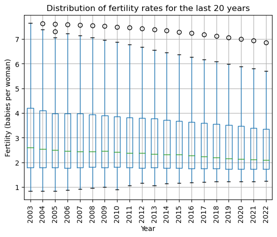

```python
fertility_df.loc[:,str(int(last_20_years[0])):current_year].boxplot()
plt.title('Distribution of fertility rates for the last 20 years')
plt.xlabel('Year')
plt.ylabel('Fertility (babies per woman)')
plt.xticks(rotation='vertical');
```

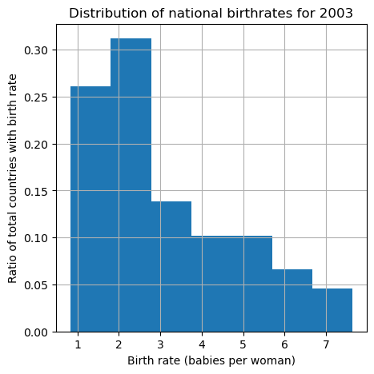

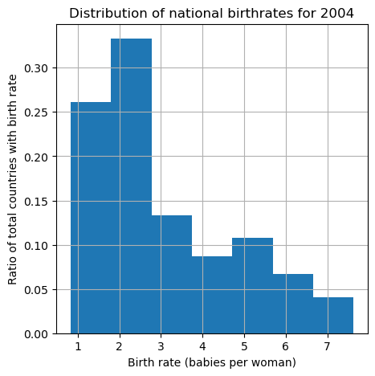

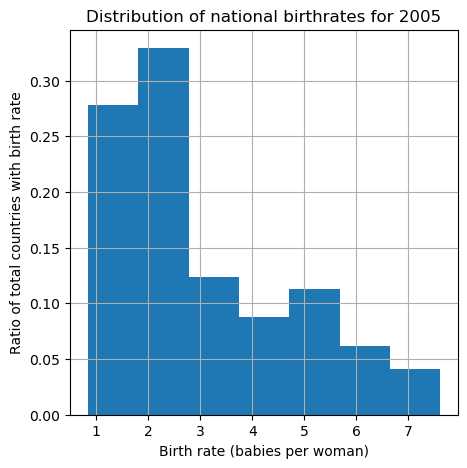

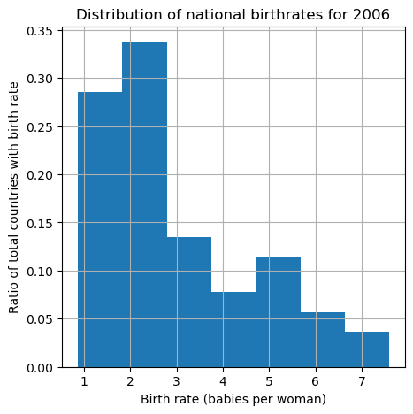

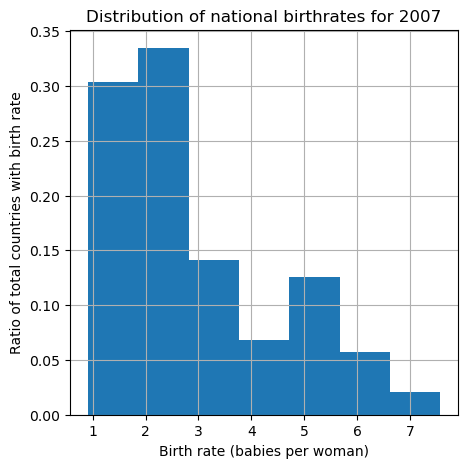

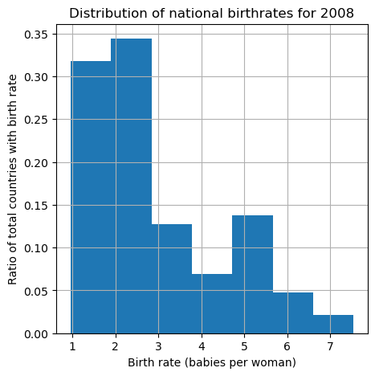

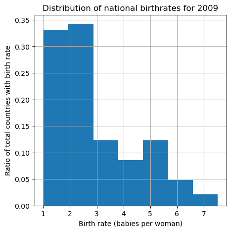

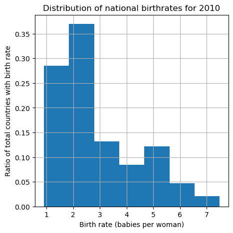

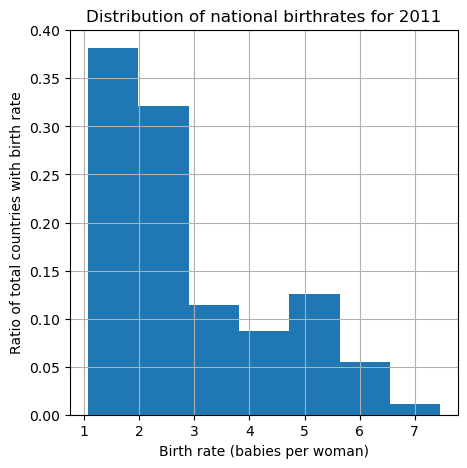

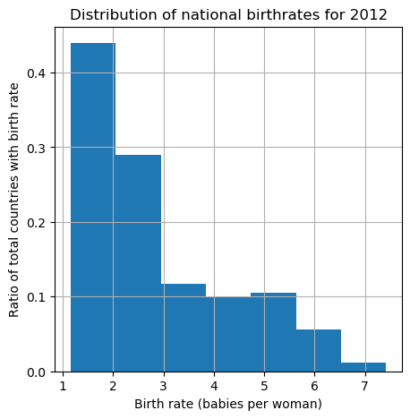

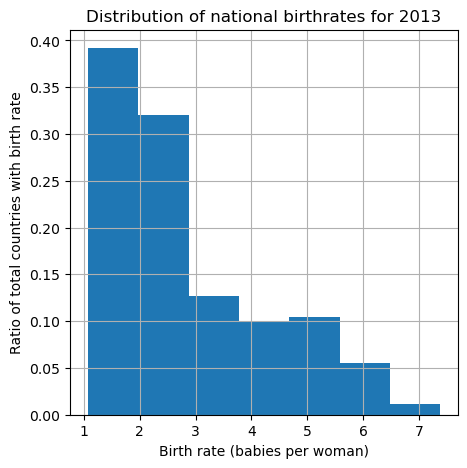

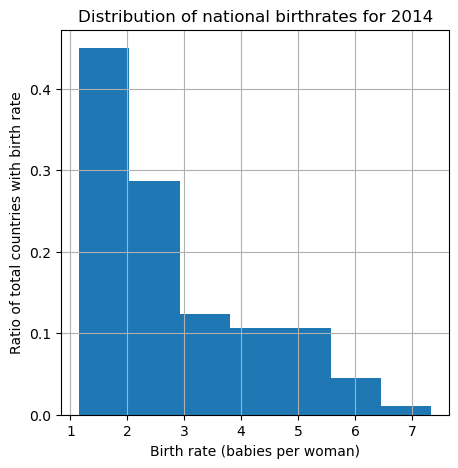

[8 more figures not shown]

```python
for year in last_20_years:
    values = fertility_df[str(year)]
    values.hist(density=True, bins=math.floor(values.max()), figsize=(5,5))
    plt.xlabel('Birth rate (babies per woman)')
    plt.ylabel('Ratio of total countries with birth rate')
    plt.title(f'Distribution of national birthrates for {year}')
    plt.show();
```

Each bar is intended to roughly approximate the increment of each additional baby to the fertility rate. The charts show that the 2 leftmost bars (corresponding to the lowest recorded birth rates) have consistently contained the birthrates for the highest percentage of countries.

#### Per Capita Income

```python
period_size = 50
period_buckets = [
    (str(int(current_year) - period_size * 1), current_year),
    (str(int(current_year) - period_size * 2), str(int(current_year) - period_size * 1)),
    (str(int(current_year) - period_size * 3), str(int(current_year) - period_size * 2)),
    (str(int(current_year) - period_size * 4), str(int(current_year) - period_size * 3)),
]
period_buckets
```

```
[('1972', '2022'), ('1922', '1972'), ('1872', '1922'), ('1822', '1872')]
```

The code above creates 4 buckets with a size of 50 years each, starting from the current year and going back 200 years.

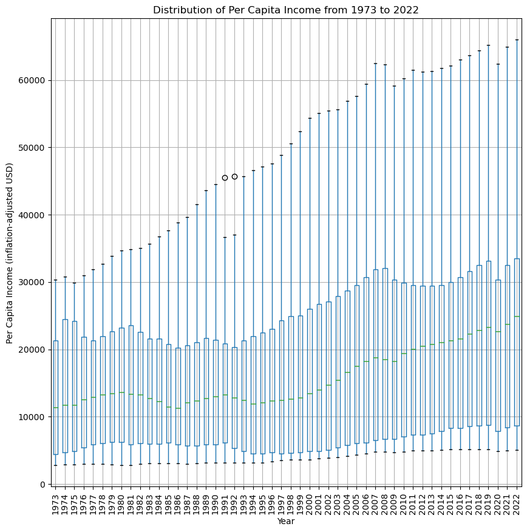

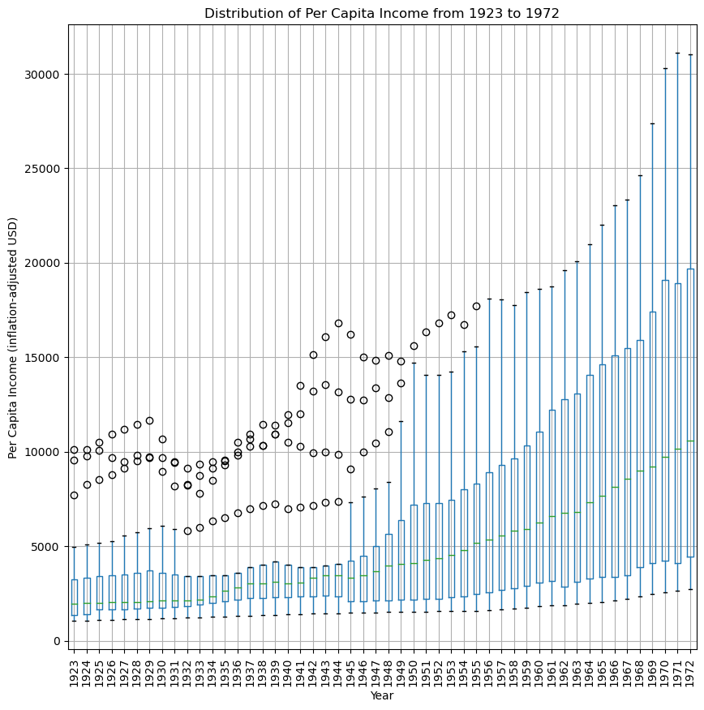

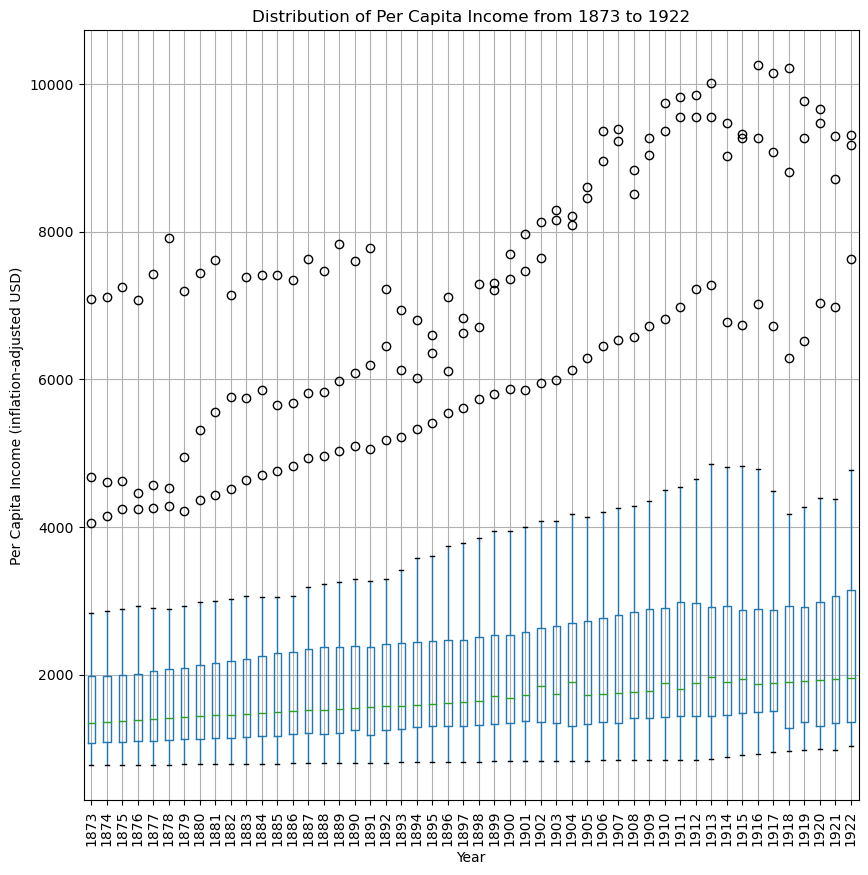

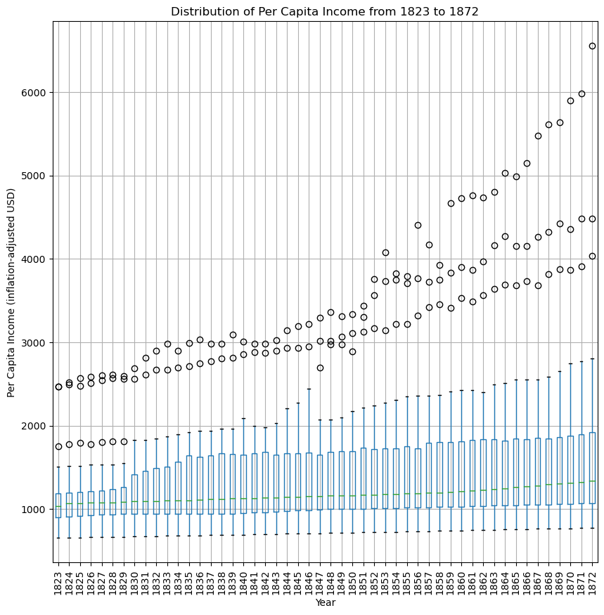

```python
for period_start, period_end in period_buckets:
    period_start = str(int(period_start) + 1)
    merged_income_country.groupby('sub_region_name').mean(numeric_only=True).loc[:,period_start:period_end].boxplot(figsize=(10,10))
    plt.ylabel('Per Capita Income (inflation-adjusted USD)')
    plt.xlabel('Year')
    plt.title(f'Distribution of Per Capita Income from {period_start} to {period_end}')
    plt.xticks(rotation='vertical')
    plt.show();
```

The charts above show the distribution of per capita income over the last 200 years, in 50 year buckets. One striking observation is that the number of outliers (the empty circles) has reduced as the years go by. That would seem to suggest that the world's wealth has become more evenly distributed over this period. Another interesting observation is that the range that should contain most values (the top and bottom dashes above and below each box) has grown noticeably beginning from about 1950. That suggests a widening gap between the richest and poorest countries, even though overall rates have been on the rise throughout that period.

#### Life Expectancy

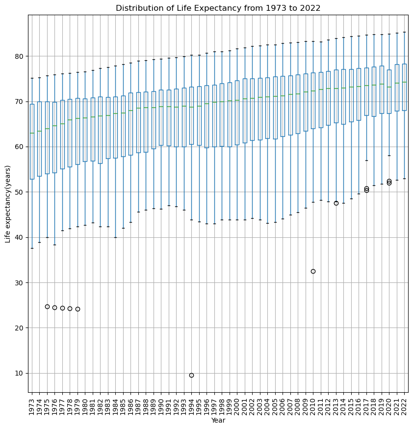

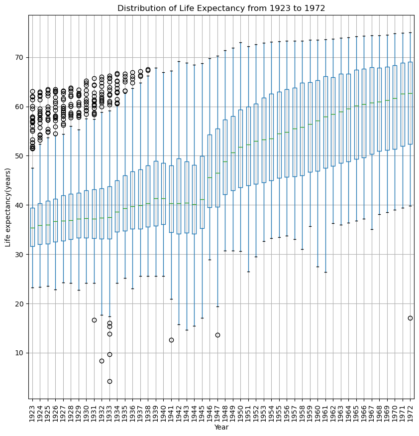

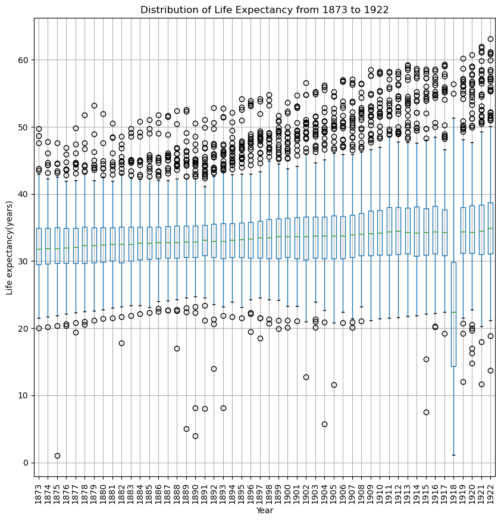

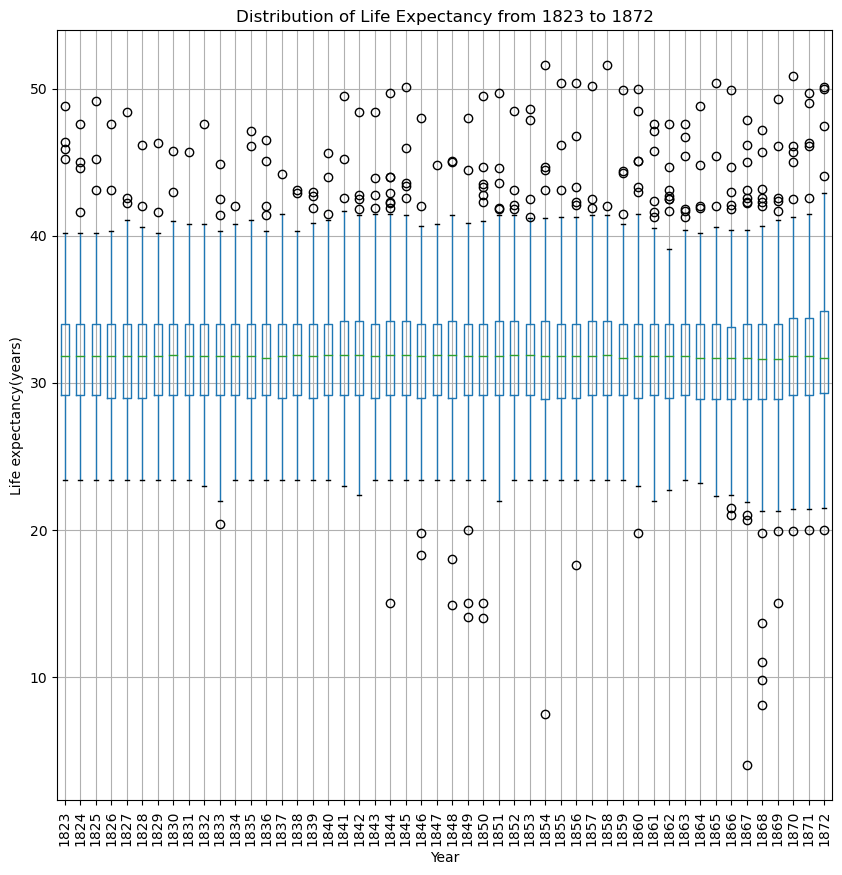

```python
for period_start, period_end in period_buckets:
    period_start = str(int(period_start) + 1)
    merged_income_life_exp_df.loc[:,period_start:period_end].boxplot(figsize=(10,10))
    plt.ylabel('Life expectancy(years)')
    plt.xlabel('Year')
    plt.title(f'Distribution of Life Expectancy from {period_start} to {period_end}')
    plt.xticks(rotation='vertical')
    plt.show();
```

The charts above show the distribution of life expectancy over the past 200 years, in 50 year buckets. The first striking observation is the relative flatness of life expectancy over the first 100 years of the period, followed by a sizeable rise (more than a doubling for the highest value!) in the second 100 years of the period. The second striking observation is that the number of outliers also drops noticeably in the second 100 years, suggesting that in recent years the majority of countries have benefitted from the driver's of higher life expectancy.

### Q1: Which countries currently have the highest and lowest fertility rates?

#### Highest Fertility Rates

```python
current_fertility = fertility_df[current_year]
current_fertility = current_fertility.set_axis(fertility_df.country, copy=False)
current_fertility = current_fertility.sort_values(ascending=False)
current_fertility.head()
```

```
country
niger               6.86
somalia             5.71
congo,_dem._rep.    5.52
mali                5.51
chad                5.36
Name: 2022, dtype: float64
```

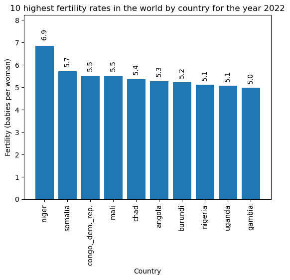

```python
current_fertility_highest = current_fertility[:10]

plt.bar(x=np.arange(10), height=current_fertility_highest)
plt.xticks(np.arange(10), current_fertility_highest.keys(), rotation='vertical')
for i, val in enumerate(current_fertility_highest):
    plt.text(i, val * 1.05, f'{val:.1f}', horizontalalignment='center', rotation='vertical')
plt.title(f'10 highest fertility rates in the world by country for the year {current_year}')
plt.ylim(0, current_fertility_highest.max() * 1.2)
plt.xlabel('Country')
plt.ylabel('Fertility (babies per woman)')
plt.show();
```

The chart above indicates high population growth rates in some countries, with 5 babies per woman being the smallest rate of the top 10 countries.

#### Lowest Fertility Rates

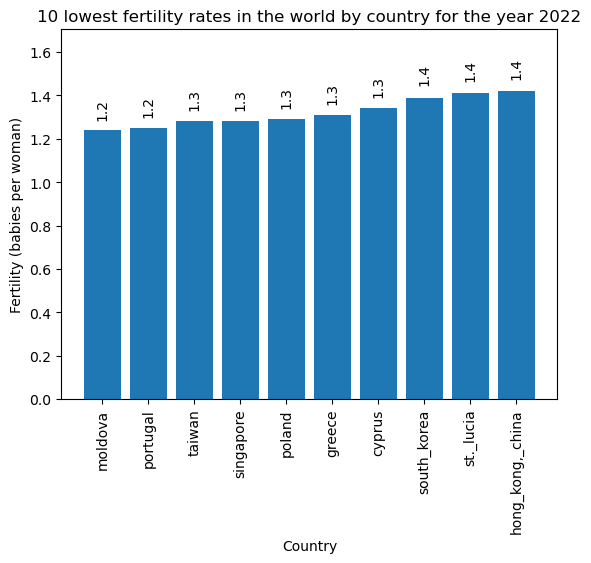

```python
current_fertility_lowest = current_fertility[-10:]
current_fertility_lowest.sort_values(ascending=True, inplace=True)

plt.bar(x=np.arange(10), height=current_fertility_lowest)
plt.xticks(np.arange(10), current_fertility_lowest.keys(), rotation='vertical')
for i, val in enumerate(current_fertility_lowest):
    plt.text(i, val * 1.05, f'{val:.1f}', horizontalalignment='center', rotation='vertical')
plt.title(f'10 lowest fertility rates in the world by country for the year {current_year}')
plt.ylim(0, current_fertility_lowest.max() * 1.2)
plt.xlabel('Country')
plt.ylabel('Fertility (babies per woman)')
plt.show();
```

The chart above indicates that some countries have declining populations. `2.1` is the [approximate threshold](https://www.bbc.com/news/health-53409521) needed to maintain a population's size, but all the countries shown in the chart have population growth rates of 1.4 or less.

### Q2: How have the fertility rates for those countries been trending in the last 20 years?

#### Countries with highest current fertility rates

```python
fertility_df_highest_current = fertility_df.query('country in ["' + '","'.join(list(current_fertility_highest.keys())) + '"]')
fertility_df_highest_current = fertility_df_highest_current.loc[:, ['country'] + [str(year) for year in last_20_years]]
fertility_df_highest_current
```

|  | country | 2003 | 2004 | 2005 | 2006 | 2007 | 2008 | 2009 | 2010 | 2011 | ... | 2013 | 2014 | 2015 | 2016 | 2017 | 2018 | 2019 | 2020 | 2021 | 2022 |
| --- | --- | --- | --- | --- | --- | --- | --- | --- | --- | --- | --- | --- | --- | --- | --- | --- | --- | --- | --- | --- | --- |
| 2 | angola | 6.54 | 6.50 | 6.47 | 6.42 | 6.37 | 6.31 | 6.24 | 6.16 | 6.08 | ... | 5.92 | 5.84 | 5.77 | 5.69 | 5.62 | 5.55 | 5.48 | 5.41 | 5.34 | 5.28 |
| 12 | burundi | 6.82 | 6.76 | 6.69 | 6.62 | 6.53 | 6.45 | 6.35 | 6.26 | 6.16 | ... | 5.96 | 5.87 | 5.78 | 5.70 | 5.62 | 5.53 | 5.45 | 5.38 | 5.30 | 5.22 |
| 37 | congo,_dem._rep. | 6.81 | 6.76 | 6.71 | 6.66 | 6.61 | 6.57 | 6.52 | 6.47 | 6.42 | ... | 6.30 | 6.24 | 6.17 | 6.09 | 6.02 | 5.92 | 5.82 | 5.72 | 5.62 | 5.52 |
| 68 | gambia | 5.88 | 5.86 | 5.84 | 5.81 | 5.79 | 5.76 | 5.74 | 5.71 | 5.68 | ... | 5.60 | 5.54 | 5.49 | 5.43 | 5.36 | 5.29 | 5.22 | 5.14 | 5.07 | 4.99 |
| 118 | mali | 6.84 | 6.82 | 6.79 | 6.76 | 6.72 | 6.67 | 6.61 | 6.55 | 6.47 | ... | 6.32 | 6.23 | 6.15 | 6.06 | 5.97 | 5.88 | 5.79 | 5.70 | 5.60 | 5.51 |
| 132 | niger | 7.64 | 7.63 | 7.61 | 7.59 | 7.57 | 7.54 | 7.52 | 7.49 | 7.46 | ... | 7.38 | 7.34 | 7.29 | 7.24 | 7.18 | 7.13 | 7.07 | 7.00 | 6.93 | 6.86 |
| 133 | nigeria | 6.04 | 6.01 | 5.99 | 5.96 | 5.93 | 5.90 | 5.87 | 5.84 | 5.80 | ... | 5.71 | 5.65 | 5.59 | 5.53 | 5.46 | 5.39 | 5.32 | 5.25 | 5.18 | 5.11 |
| 164 | somalia | 7.45 | 7.38 | 7.31 | 7.23 | 7.14 | 7.06 | 6.96 | 6.87 | 6.77 | ... | 6.56 | 6.46 | 6.37 | 6.27 | 6.17 | 6.08 | 5.98 | 5.89 | 5.80 | 5.71 |
| 175 | chad | 7.21 | 7.15 | 7.07 | 6.99 | 6.90 | 6.80 | 6.70 | 6.59 | 6.48 | ... | 6.26 | 6.16 | 6.05 | 5.95 | 5.85 | 5.75 | 5.65 | 5.55 | 5.45 | 5.36 |
| 187 | uganda | 6.72 | 6.65 | 6.58 | 6.51 | 6.42 | 6.34 | 6.25 | 6.15 | 6.06 | ... | 5.87 | 5.78 | 5.68 | 5.59 | 5.50 | 5.41 | 5.32 | 5.24 | 5.15 | 5.06 |

10 rows × 21 columns

First, the fertility rates of the last 20 years are collected for the countries with the highest current fertility rates.

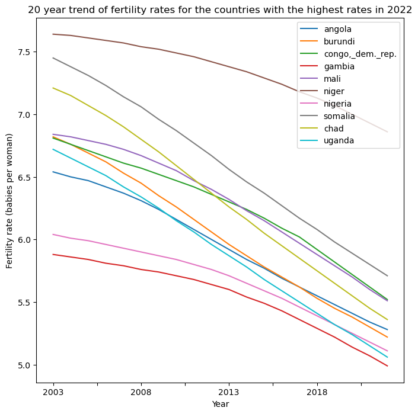

```python
fertility_df_highest_current.transpose().iloc[1:,:].plot(figsize=(8,8)).legend(fertility_df_highest_current.country)
plt.title(f'20 year trend of fertility rates for the countries with the highest rates in {current_year}')
plt.xlabel('Year')
plt.ylabel('Fertility rate (babies per woman)');
```

The chart above suggests that fertility rates have recently been dropping for all the countries. Note that the dataframe had to be transposed (i.e. the axes had to be flipped) in order to generate this chart.

#### Countries with lowest current fertility rates

```python
fertility_df_lowest_current = fertility_df.query('country in ["' + '","'.join(list(current_fertility_lowest.keys())) + '"]')
fertility_df_lowest_current = fertility_df_lowest_current.loc[:, ['country'] + [str(year) for year in range(int(current_year) - 19, int(current_year) + 1)]]
fertility_df_lowest_current
```

|  | country | 2003 | 2004 | 2005 | 2006 | 2007 | 2008 | 2009 | 2010 | 2011 | ... | 2013 | 2014 | 2015 | 2016 | 2017 | 2018 | 2019 | 2020 | 2021 | 2022 |
| --- | --- | --- | --- | --- | --- | --- | --- | --- | --- | --- | --- | --- | --- | --- | --- | --- | --- | --- | --- | --- | --- |
| 44 | cyprus | 1.58 | 1.55 | 1.52 | 1.50 | 1.48 | 1.46 | 1.44 | 1.42 | 1.41 | ... | 1.37 | 1.36 | 1.35 | 1.34 | 1.34 | 1.34 | 1.33 | 1.33 | 1.34 | 1.34 |
| 71 | greece | 1.36 | 1.38 | 1.40 | 1.42 | 1.44 | 1.44 | 1.43 | 1.41 | 1.39 | ... | 1.35 | 1.33 | 1.31 | 1.31 | 1.30 | 1.30 | 1.30 | 1.30 | 1.30 | 1.31 |
| 78 | hong_kong,_china | 0.95 | 0.96 | 0.97 | 0.99 | 1.02 | 1.05 | 1.08 | 1.12 | 1.15 | ... | 1.22 | 1.24 | 1.27 | 1.30 | 1.32 | 1.34 | 1.36 | 1.38 | 1.40 | 1.42 |
| 99 | south_korea | 1.21 | 1.18 | 1.17 | 1.16 | 1.16 | 1.17 | 1.18 | 1.19 | 1.21 | ... | 1.24 | 1.26 | 1.28 | 1.30 | 1.31 | 1.33 | 1.35 | 1.36 | 1.38 | 1.39 |
| 105 | st._lucia | 1.83 | 1.74 | 1.68 | 1.63 | 1.60 | 1.57 | 1.56 | 1.54 | 1.52 | ... | 1.50 | 1.48 | 1.47 | 1.46 | 1.45 | 1.44 | 1.43 | 1.42 | 1.42 | 1.41 |
| 113 | moldova | 1.25 | 1.22 | 1.22 | 1.23 | 1.24 | 1.26 | 1.27 | 1.27 | 1.27 | ... | 1.26 | 1.26 | 1.25 | 1.24 | 1.23 | 1.23 | 1.23 | 1.23 | 1.23 | 1.24 |
| 145 | poland | 1.28 | 1.28 | 1.30 | 1.32 | 1.34 | 1.36 | 1.37 | 1.37 | 1.36 | ... | 1.33 | 1.32 | 1.31 | 1.30 | 1.29 | 1.29 | 1.29 | 1.29 | 1.29 | 1.29 |
| 148 | portugal | 1.44 | 1.43 | 1.42 | 1.40 | 1.38 | 1.36 | 1.34 | 1.33 | 1.31 | ... | 1.28 | 1.26 | 1.25 | 1.25 | 1.24 | 1.24 | 1.24 | 1.24 | 1.24 | 1.25 |
| 160 | singapore | 1.27 | 1.26 | 1.26 | 1.28 | 1.29 | 1.28 | 1.26 | 1.26 | 1.26 | ... | 1.25 | 1.25 | 1.24 | 1.25 | 1.25 | 1.26 | 1.27 | 1.27 | 1.28 | 1.28 |
| 185 | taiwan | 1.24 | 1.18 | 1.12 | 1.12 | 1.10 | 1.05 | 1.03 | 0.90 | 1.07 | ... | 1.07 | 1.15 | 1.17 | 1.19 | 1.21 | 1.22 | 1.24 | 1.25 | 1.27 | 1.28 |

10 rows × 21 columns

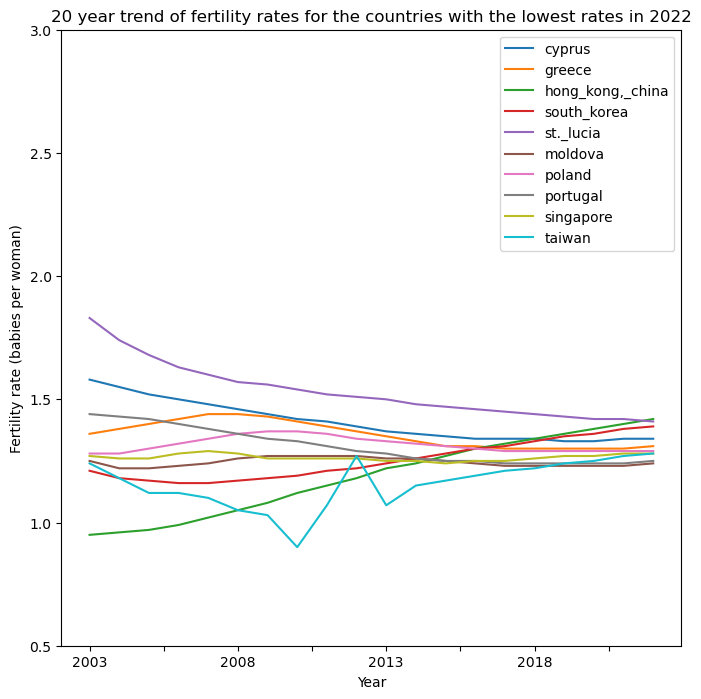

```python
# set ylim to a range of 2.5 for uniformity with the plot for highest fertility countries
fertility_df_lowest_current.transpose().iloc[1:,:].plot(figsize=(8,8), ylim=(0.5, 3)).legend(fertility_df_lowest_current.country)
plt.title(f'20 year trend of fertility rates for the countries with the lowest rates in {current_year}')
plt.xlabel('Year')
plt.ylabel('Fertility rate (babies per woman)');
```

### Q3: Which sub-regions of the world are currently the richest, and which are the poorest?

```python
current_richest_regions = merged_income_country.groupby('sub_region_name').mean(numeric_only=True)[current_year].sort_values(ascending=False)
```

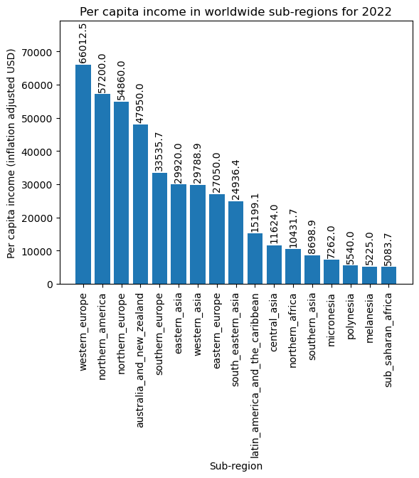

```python
current_richest_regions_ticks = np.arange(len(current_richest_regions))
plt.bar(x=current_richest_regions_ticks, height=current_richest_regions)
plt.xticks(current_richest_regions_ticks, current_richest_regions.index, rotation='vertical')
for i, val in enumerate(current_richest_regions):
    plt.text(i, val + 750, f'{val:.1f}', rotation='vertical', horizontalalignment='center', verticalalignment='bottom')

plt.ylim(0, current_richest_regions.max() * 1.2)
plt.title(f'Per capita income in worldwide sub-regions for {current_year}')
plt.xlabel('Sub-region')
plt.ylabel('Per capita income (inflation adjusted USD)');
```

The chart above suggests that the world's richest societies are concentrated in the area colloquially known as the "West" i.e. Europe, North America, Australia and New Zealand. Sub-Saharan Africa and island nations around Australia (Polynesia, Micronesia, and Melanesia) have by far the poorest societies, with Asia and the Middle East occupying the middle of the range alongside Latin America.

### Q4: How has that wealth pattern changed over the past 200 years?

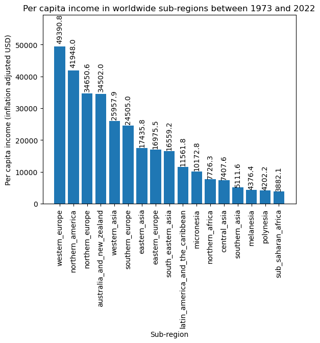

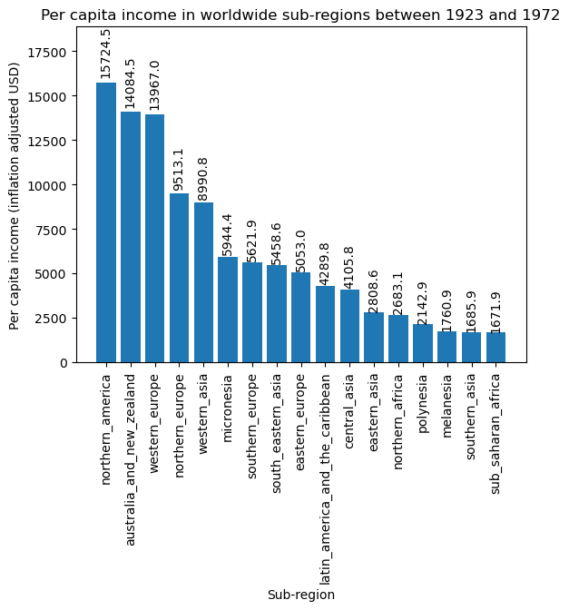

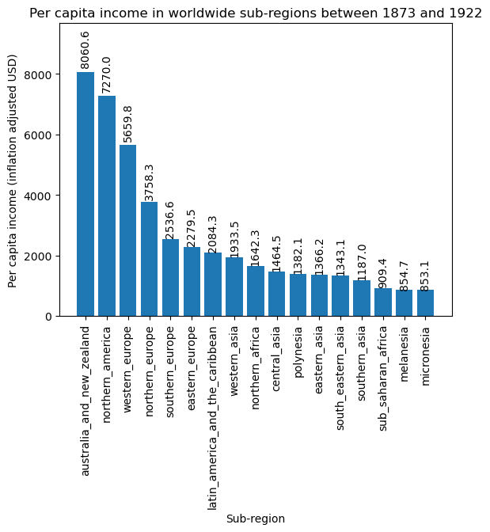

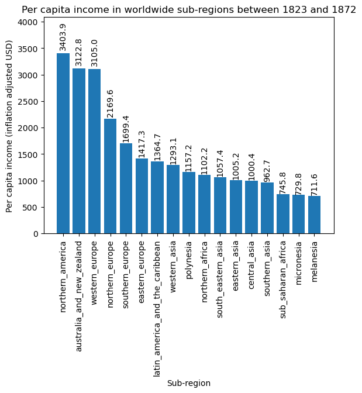

```python
for period_start, period_end in period_buckets:
    period_start = str(int(period_start) + 1)
    period_mean_income_per_sub_region = merged_income_country.groupby('sub_region_name').mean(numeric_only=True).loc[:, period_start:period_end].mean(axis=1).sort_values(ascending=False)
    bar_ticks = np.arange(len(period_mean_income_per_sub_region))
    plt.bar(x=bar_ticks, height=period_mean_income_per_sub_region)
    plt.xticks(bar_ticks, period_mean_income_per_sub_region.index, rotation='vertical')
    for i, val in enumerate(period_mean_income_per_sub_region):
        # add 2% of the value for some space above the top of the bar
        plt.text(i, val * 1.02, f'{val:.1f}', verticalalignment='bottom', horizontalalignment='center', rotation='vertical')

    # add 20% of the max to the y scale so the highest text label doesn't overflow the top of the chart
    plt.ylim(0, period_mean_income_per_sub_region.max() * 1.2)
    plt.title(f'Per capita income in worldwide sub-regions between {period_start} and {period_end}')
    plt.xlabel('Sub-region')
    plt.ylabel('Per capita income (inflation adjusted USD)')
    plt.figure(figsize=(20,20))
    plt.show();
```

The charts above indicate that the composition of the extremes have not changed much in the last 200 years. The "West" has always recorded the highest per capita income during that period, and Sub-Saharan Africa and Melanesia have recorded the lowest. However, some interesting changes occurred over that period.

#### Micronesia

Micronesia has experienced quite a swing in its fortunes compared to other regions. For the oldest and second oldest buckets (1823 - 1872 and 1873 - 1922, respectively) it was the second poorest and poorest region, respectively. However, from 1923 to 1972 it shot up to the top of the mid range, behind only the "West" and western Asia. The countries within Micronesia are shown below:

```python
print(merged_income_country[merged_income_country.sub_region_name == 'micronesia'].country.unique())
```

```
['micronesia,_fed._sts.' 'kiribati' 'marshall_islands' 'nauru' 'palau']
```

A decent history lesson is likely necessary to fully investigate the reasons for such an impressive jump, nonetheless it's certainly noteworthy! More so, further investigation is also needed to determine the spread of that newfound wealth within the population of that region during that period.

#### Polynesia

Polynesia appears to have experienced the reverse change in relative fortunes. In the oldest bucket Polynesia was firmly in the middle of the pack, but it steadily fell lower until it became the second poorest region in the most recent bucket, ahead of only Sub-Saharan Africa. The countries in Polynesia are:

```python
print(merged_income_country[merged_income_country.sub_region_name == 'polynesia'].country.unique())
```

```
['tonga' 'tuvalu' 'samoa']
```

Similar to Micronesia, detecting the full story of what happened here is beyond the scope of this exploration.

### Q5: Which sub-regions of the world currently have the highest and lowest life expectancies?

```python
current_highest_life_exp = merged_life_exp_country_df.groupby('sub_region_name').mean(numeric_only=True).loc[:, current_year].sort_values(ascending=False)
```

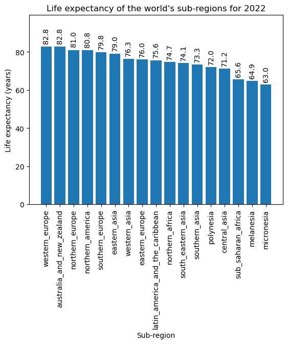

```python
current_highest_life_exp_ticks = np.arange(len(current_highest_life_exp))
plt.bar(x=current_highest_life_exp_ticks, height=current_highest_life_exp)
plt.xticks(current_highest_life_exp_ticks, labels=current_highest_life_exp.index, rotation='vertical')
plt.ylim((0, current_highest_life_exp.max() * 1.2))
for i, val in enumerate(current_highest_life_exp):
    plt.text(i, val * 1.02, f'{val:.1f}', verticalalignment='bottom', horizontalalignment='center', rotation='vertical')
plt.title(f"Life expectancy of the world's sub-regions for {current_year}")
plt.xlabel('Sub-region')
plt.ylabel('Life expectancy (years)')
plt.show();
```

The chart above suggests that the distribution of life expectancy follows a similar pattern to what was seen with per capita income. The "West" has the highest life expectancy, and Sub-Saharan Africa, Melanesia and Micronesia have the lowest.